# Using atacr for Enriched RNAseq and ATACseq analysis

Dan MacLean

2018-03-21

*atacr* is a package for creating statistics and diagnostic plots for short read sequence data from capture enriched RNAseq and ATACseq experiments.

This vignette provides a brief overview of the capabilities of `atacr`.

## Sample data

> The function `simulate_counts()` will give us a small simulated data set of three replicates from a control and treatment. Each of the six sets of counts follows a mixed distribution of 10 counts drawn from a log-normal distribution with logmean 4 and SD 1, and 40 counts with logmean 10 and SD 1. This mimics the enrichment pattern we see with capture enriched data. 10 of the counts are multiplied by a value drawn from the normal distribution with mean 2 and SD 1 so can appear differentially expressed. These counts represent bait-windows - regions of the genome for which baits were designed. The bait-window counts are mixed with 50 non-bait-windows which have 0 counts.

```r
library(atacr)
counts <-simulate_counts()
```

## Experiment Summary Information

It’s very easy to get information on the coverage for bait/non-bait windows on a per sample basis

```r
summary(counts)
```

```
## ATAC-seq experiment of 2 treatments in 6 samples
##  Treatments: control,treatment
##  Samples: control_001,control_002,control_003,treatment_001,treatment_002,treatment_003
##  Bait regions used: 50
##  Total Windows: 100
##
##  On/Off target read counts:
##           sample off_target on_target percent_on_target
## 1   control_001          0   1096557               100
## 2   control_002          0   1195717               100
## 3   control_003          0   1103689               100
## 4 treatment_001          0    997809               100
## 5 treatment_002          0   1102814               100
## 6 treatment_003          0   1375378               100
##  Quantiles:
##  $bait_windows
##     control_001 control_002 control_003 treatment_001 treatment_002
## 1%         7.37        0.00        3.45         18.68         10.31
## 5%        35.50       27.55       26.15         52.40         43.95
## 95%    77893.35    89079.70    71063.25      68795.85      95217.85
## 99%   113062.17   180385.21   150238.19     117918.69     113095.22
##     treatment_003
## 1%           2.00
## 5%          57.25
## 95%     110209.25
## 99%     138024.45
##
## $non_bait_windows
##     control_001 control_002 control_003 treatment_001 treatment_002
## 1%           NA          NA          NA            NA            NA
## 5%           NA          NA          NA            NA            NA
## 95%          NA          NA          NA            NA            NA
## 99%          NA          NA          NA            NA            NA
##     treatment_003
## 1%             NA
## 5%             NA
## 95%            NA
## 99%            NA
##
##  Read depths:
##           sample off_target on_target
## 1   control_001         NA  21931.14
## 2   control_002         NA  23914.34
## 3   control_003         NA  22073.78
## 4 treatment_001         NA  19956.18
## 5 treatment_002         NA  22056.28
## 6 treatment_003         NA  27507.56
```

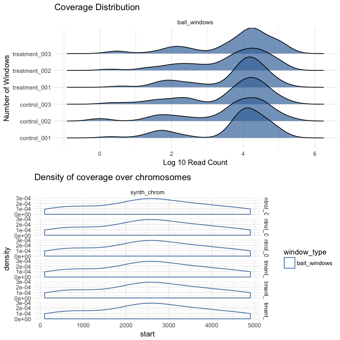

```r
plot(counts)
```

These plots can be generated individually with the following functions

## QC Plots

### Plot for coverage by sequence and sample

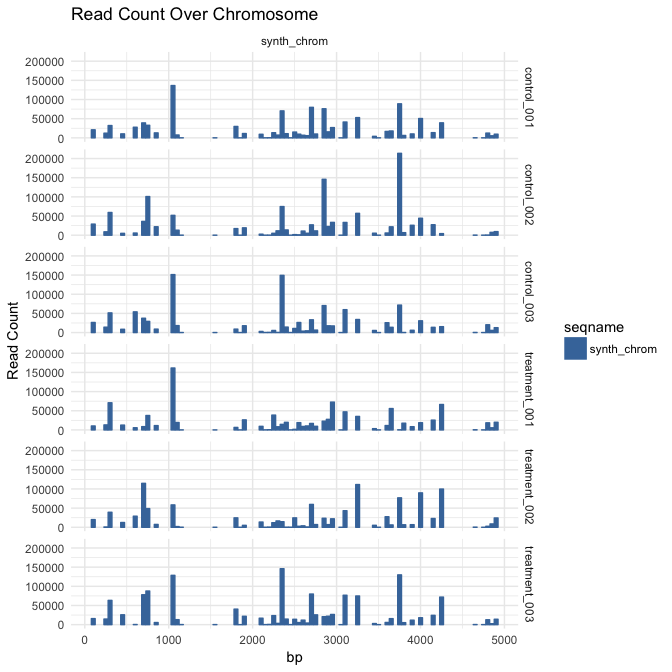

```r
plot_count_by_chromosome(counts)
```

### Correlations between sample counts

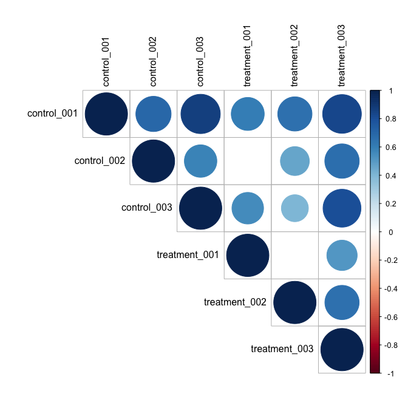

```r
sample_correlation_plot(counts)
```

### Count windows below a threshold.

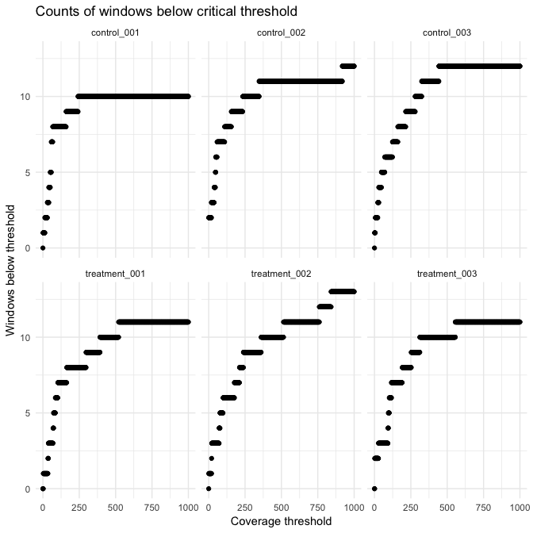

```r
windows_below_coverage_threshold_plot(counts, which = "bait_windows", from=0, to=1000)
```

### MA plots

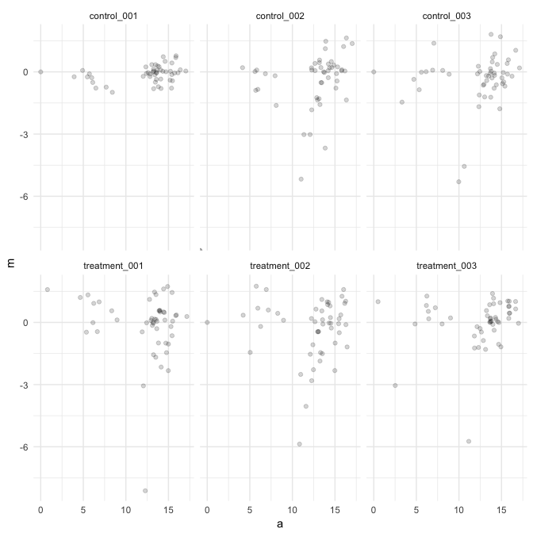

```r
ma_plot(counts)
```

## Normalisation

Normalisation strategies are easy to implement with `atacr` and helpful functions are included

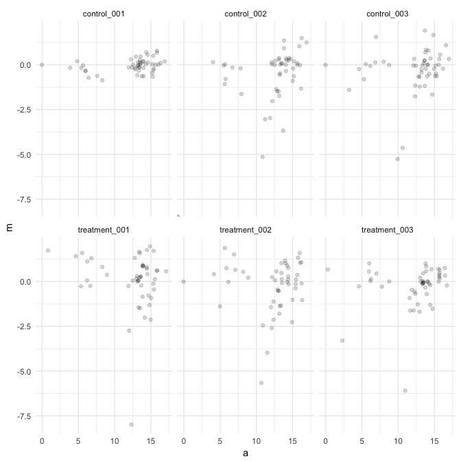

```r
counts$library_size_normalised <- library_size_normalisation(counts)
ma_plot(counts, which = "library_size_normalised")
```

Normalisation by control windows. Requires a text file with the control window positions

```r
window_file <- "control_windows.txt"
counts$control_window_normalisation <- control_window_normalise(sim_counts, window_file)
```

## Detect differentially expressed/accessible windows

Using a simple bootstrap *t*-test method for simple two-way comparisons.

```r
result <- estimate_fdr(sim_counts, "treatment", "control", which = "bait_windows")

pander::pandoc.table(head(result))
```

Table continues below

| window | t | p_value | fdr | mean_count_a | mean_count_b |
| --- | --- | --- | --- | --- | --- |
| synth_chrom:1-50:- | 6.418 | 0 | 0 | 87 | 25 |
| synth_chrom:51-100:+ | -7.602 | 0 | 0 | 1.333 | 30.67 |
| synth_chrom:101-150:+ | 4.744 | 0 | 0 | 79.67 | 28.67 |
| synth_chrom:151-200:+ | 2.654 | 0 | 0 | 56 | 30.67 |
| synth_chrom:201-250:+ | 4.181 | 0 | 0 | 44.33 | 27.67 |
| synth_chrom:251-300:+ | 3.801 | 0 | 0 | 47.33 | 32.67 |

| sd_a | sd_b | log2_fc | is_sig |
| --- | --- | --- | --- |
| 16.09 | 4.583 | 1.799 | TRUE |
| 0.5774 | 6.658 | -4.524 | TRUE |
| 17.79 | 5.508 | 1.475 | TRUE |
| 15.59 | 5.508 | 0.8688 | TRUE |
| 4.726 | 5.033 | 0.6802 | TRUE |
| 5.859 | 3.215 | 0.535 | TRUE |

This can also be done for multiclass designs with multiple samples against a common reference.

```r
multi_result <- estimate_fdr_multiclass(sim_counts, "control", which = "bait_windows")
pander::pandoc.table(head(multi_result))
```

Table continues below

| window | t | p_value | fdr | mean_count_a |
| --- | --- | --- | --- | --- |
| synth_chrom:1-50:- | 6.418 | 0 | 0 | 87 |
| synth_chrom:51-100:+ | -7.602 | 0.1 | 0.4342 | 1.333 |
| synth_chrom:101-150:+ | 4.744 | 0 | 0 | 79.67 |
| synth_chrom:151-200:+ | 2.654 | 0 | 0 | 56 |
| synth_chrom:201-250:+ | 4.181 | 0 | 0 | 44.33 |
| synth_chrom:251-300:+ | 3.801 | 0.1 | 0.4342 | 47.33 |

| mean_count_b | sd_a | sd_b | log2_fc | is_sig | a | b |
| --- | --- | --- | --- | --- | --- | --- |
| 25 | 16.09 | 4.583 | 1.799 | TRUE | treatment | control |
| 30.67 | 0.5774 | 6.658 | -4.524 | FALSE | treatment | control |
| 28.67 | 17.79 | 5.508 | 1.475 | TRUE | treatment | control |
| 30.67 | 15.59 | 5.508 | 0.8688 | TRUE | treatment | control |
| 27.67 | 4.726 | 5.033 | 0.6802 | TRUE | treatment | control |
| 32.67 | 5.859 | 3.215 | 0.535 | FALSE | treatment | control |

## Visualise windows with the same pattern across experiments

```r
library(UpSetR)
u <- make_UpSetR(multi_result)

upset(fromList(u))
```

```
## geom_path: Each group consists of only one observation. Do you need to
## adjust the group aesthetic?
```

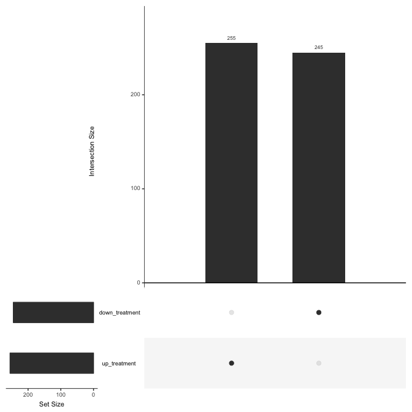